# Drop Labels from a Table

```r
library(tidyREDCap)
```

# The Problem

The `tidyREDCap` package creates data sets with labelled columns.

```r
tidyREDCap::import_instruments(
  url = "https://bbmc.ouhsc.edu/redcap/api/",
  token = keyring::key_get("REDCapR_test")
)
```

If you would like to see the labels on the data set `demographics`, you can use the RStudio function `View()`, as shown below.

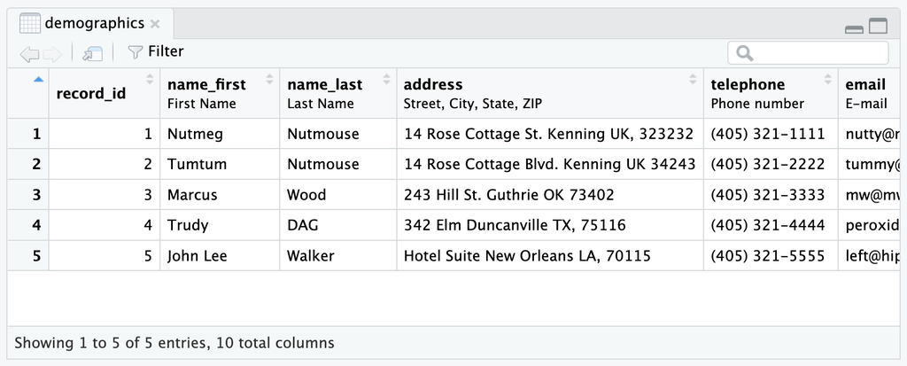

```r
View(demographics)
```

However, some functions do not work well with labeled variables. For example:

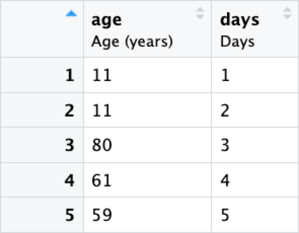

```r
demographics |>
  rowwise() |>
  mutate(x = sum(c_across(c(age, days))))
```

```
#> Error in `mutate()`:
#> ℹ In argument: `x = sum(c_across(c(age, days)))`.
#> ℹ In row 1.
#> Caused by error in `vec_cast.labelled.labelled()`:
#> ✖ You are trying to combine variables with different labels
#> You can use tidyREDCap::drop_label() to erase one.
```

So you need a way to drop the label off of a variable or to drop all the labels from all the variables in a dataset.

# The Solution

## Drop a single label

You can drop the label from a single variable with the `drop_label()` function. For example:

```r
new_demographics_table <- drop_label(demographics, "name_first")
# Or
new_demographics_table <- drop_label(demographics, name_first)
# Or
new_demographics_table <- demographics |> drop_label("name_first")
```

## Drop multiple labels

If you need to drop labels from multiple variables, you can drop them individually or using helper methods (i.e., `across()`).

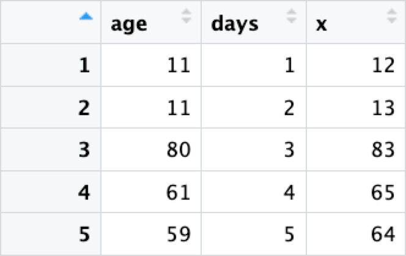

```r
demographics |>
  mutate(age = drop_label(age)) |>
  mutate(days = drop_label(days)) |>
  rowwise() |>
  mutate(x = sum(c_across(c(age, days))))
# Or
demographics |>
  mutate(across(c(age, days), drop_label)) |>
  rowwise() |>
  mutate(x = sum(c_across(c(age, days))))
```

You can use `tidyselect` helper methods (i.e., `contains()` or `starts_with()`) to include more than one variable or list them. The following code produces the same result:

```r
demographics_changed_2 <- drop_label(demographics, contains("name"))
# Same as:
demographics_changed_3 <- drop_label(demographics, name_first, name_last)
# Verifying:
identical(demographics_changed_2, demographics_changed_3)
```

> NOTE: You do not normally need to enclose the variable names in quotations outside of `tidyselect` helpers (i.e., `contains()`) though the function still operates if you choose to.

## Use inside a `mutate`

You can now use `drop_label()` inside a `mutate` pipe like this:

```r
demographics_from_mutate <- demographics |>
  mutate(name_first = drop_label(name_first))
# Or
demographics_from_mutate <- demographics |>
  mutate(across(starts_with('name'), drop_label))
```

## Drop all dataset variable labels

You can drop all the labels using the `drop_label()` function. For example:

```r
demographics_without_labels <- drop_label(demographics)
```

> NOTE: tidyREDCap versions prior to 1.2.0 handled dropping all variable labels from a dataset by using `drop_labels()`. This function can still be used, but we added a polite message to use `drop_label()` instead.

```r
demographics_without_labels <- drop_labels(demographics)
```